# tidyverse Overview: Russian Trolls

Ryan Wesslen

July 11, 2018

## Intro

### install and call packages

First, we need to get `tidyverse`. Recall, you only need to install once (but you need to do it for each computer).

After installing, you then need to call the library to “activate” it.

```r
# install packages
# install.packages("tidyverse")

# call (i.e., activate) tidyverse
library(tidyverse)
```

## load csv file

Next, let’s load the csv file from the url.

```r
url <- "http://nodeassets.nbcnews.com/russian-twitter-trolls/tweets.csv"
tweets <- read_csv(url)
```

## Count Function

With the dataframe, let’s use the `count()` function to count the number of tweets per user (user_key).

```r
# count function
count(tweets, user_key)
```

```
## # A tibble: 453 x 2
##    user_key          n
##    <chr>         <int>
##  1 4ever1937         6
##  2 4mysquad         43
##  3 6druz             5
##  4 aantiracist      37
##  5 abigailssilk     17
##  6 acejinev         65
##  7 adamchapmanjr    38
##  8 adrgreerr        13
##  9 adrienne_gg      40
## 10 agnesgrhm         1
## # ... with 443 more rows
```

```r
# assignment operator
c <- count(tweets, user_key)

# piping
c2 <- tweets %>%
  count(user_key)

# group_by and summarise
c3 <- tweets %>%
  group_by(user_key) %>%
  summarise(Count=n())
```

**Question**: What is the difference between these three dataframes?

## What were the top tweets by retweet and favorite (likes) counts?

Let’s use other `dplyr` functions to examine the top retweets…

```r
tweets %>%
  arrange(desc(retweet_count)) %>%
  select(user_key, created_str, text, retweet_count)
```

```
## # A tibble: 203,451 x 4
##    user_key        created_str         text                  retweet_count
##    <chr>           <dttm>              <chr>                         <int>
##  1 trayneshacole   2016-11-17 20:27:21 go all the way off h…         20494
##  2 gloed_up        2016-03-12 19:50:32 "#AnthonyCage was bl…         18209
##  3 crystal1johnson 2016-10-10 22:55:10 "When It’s slowly be…         13636
##  4 ten_gop         2016-10-11 02:11:02 "OMG, this new Anti-…         12078
##  5 ten_gop         2016-10-18 18:44:14 "RT the hell out of …         12042
##  6 crystal1johnson 2016-06-04 01:06:58 Muhammad Ali, the on…         11616
##  7 jenn_abrams     2016-09-18 16:42:48 "Some guy right in H…         11363
##  8 crystal1johnson 2016-10-09 01:27:00 3 Black children car…         10823
##  9 ten_gop         2016-10-20 05:40:07 "BREAKING🚨 \n\nHilla…         10467
## 10 bleepthepolice  2016-09-21 15:37:27 "Wow. Hadn't thought…         10310
## # ... with 203,441 more rows
```

… and most favorited (liked) tweets.

```r
tweets %>%
  arrange(desc(favorite_count)) %>%
  select(user_key, created_str, text, favorite_count)
```

```
## # A tibble: 203,451 x 4
##    user_key        created_str         text                 favorite_count
##    <chr>           <dttm>              <chr>                         <int>
##  1 trayneshacole   2016-11-17 20:27:21 go all the way off …          26655
##  2 jenn_abrams     2016-09-18 16:42:48 "Some guy right in …          16068
##  3 crystal1johnson 2016-10-10 22:55:10 "When It’s slowly b…          12815
##  4 ten_gop         2016-10-11 02:11:02 "OMG, this new Anti…          10867
##  5 ten_gop         2016-10-20 05:40:07 "BREAKING🚨 \n\nHill…          10437
##  6 crystal1johnson 2016-10-09 01:27:00 3 Black children ca…          10340
##  7 trayneshacole   2016-11-10 22:50:19 "White boyfriend sh…           9265
##  8 pamela_moore13  2016-06-16 23:35:47 "I would rather tak…           9242
##  9 crystal1johnson 2016-06-04 01:06:58 Muhammad Ali, the o…           8969
## 10 bleepthepolice  2016-09-21 15:37:27 "Wow. Hadn't though…           8495
## # ... with 203,441 more rows
```

We can then use ggplot to count the number of tweets per day.

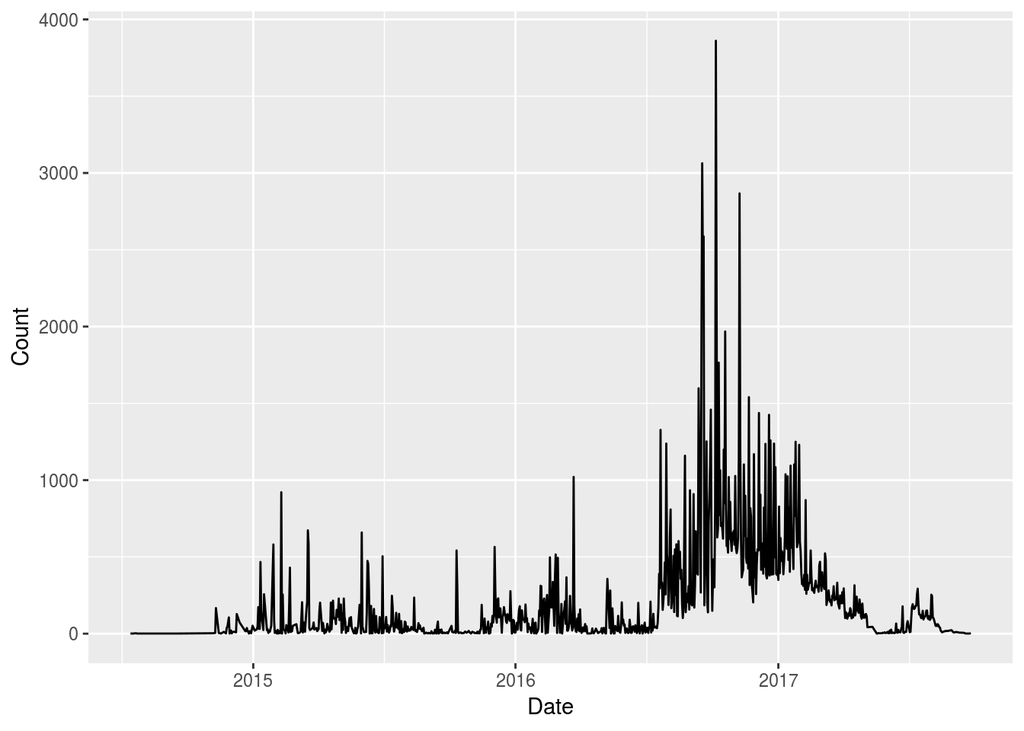

```r
# ggplot
sum <- tweets %>%
  group_by(Date = as.Date(created_str)) %>% # convert string to Date format
  summarise(Count = n())

# create ggplot
ggplot(data = sum, aes(x = Date, y = Count)) +
  geom_line()
```

```r
tweets %>%
  group_by(Date = as.Date(created_str)) %>%
  summarise(Count = n())
```

```
## # A tibble: 931 x 2
##    Date       Count
##    <date>     <int>
##  1 2014-07-14     1
##  2 2014-07-17     1
##  3 2014-07-20     2
##  4 2014-07-22     3
##  5 2014-07-23     1
##  6 2014-07-25     1
##  7 2014-07-26     1
##  8 2014-07-28     1
##  9 2014-07-29     1
## 10 2014-08-04     1
## # ... with 921 more rows
```

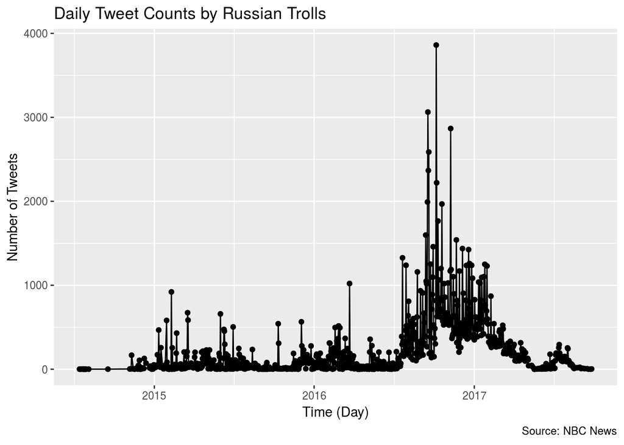

```r
ggplot(data = sum, aes(x = Date, y = Count)) +
  geom_line() +
  geom_point() +
  labs(title = "Daily Tweet Counts by Russian Trolls",
       x = "Time (Day)",
       y = "Number of Tweets",
       caption = "Source: NBC News")
```

We can also save the plot to an object (m).

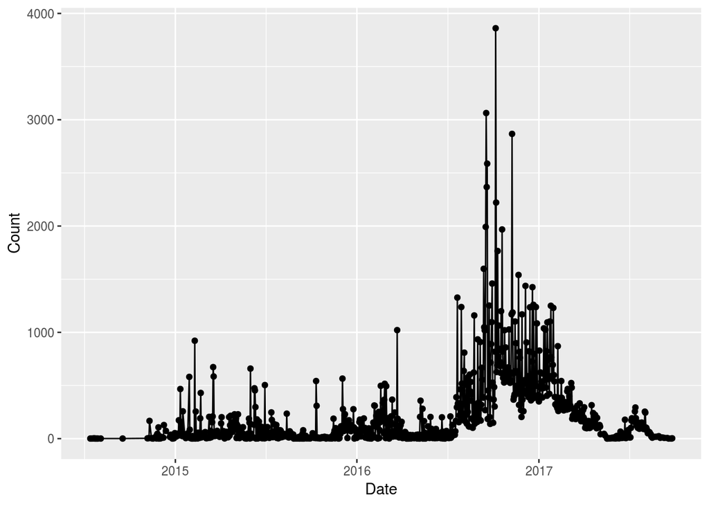

```r
# saving as an object
m <- ggplot(data = sum, aes(x = Date, y = Count)) +
  geom_line() +
  geom_point()

# you can manually call the object
m
```

With that object, you can add new layers to the plot.

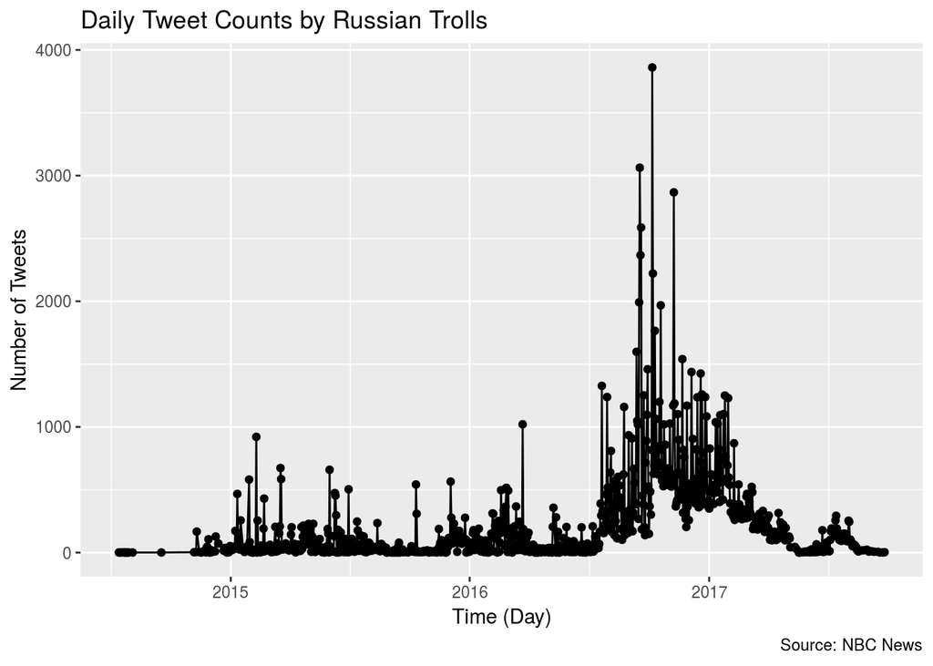

```r
# you can add layers
m + labs(title = "Daily Tweet Counts by Russian Trolls",
         x = "Time (Day)",
         y = "Number of Tweets",
         caption = "Source: NBC News")
```

## Stringr to filter text

Let’s use the `stringr` package to filter tweets that mention either #keithlamontscott or Charlotte (| is the “OR” operator).

```r
# use stringr for text filter -- part of the tidyverse
library(stringr)

term <- "#keithlamontscott|charlotte"

q <- tweets %>%
  filter(str_detect(tolower(tweets$text), tolower(term)))
```

### Add in full pipeline

Let’s now link the data

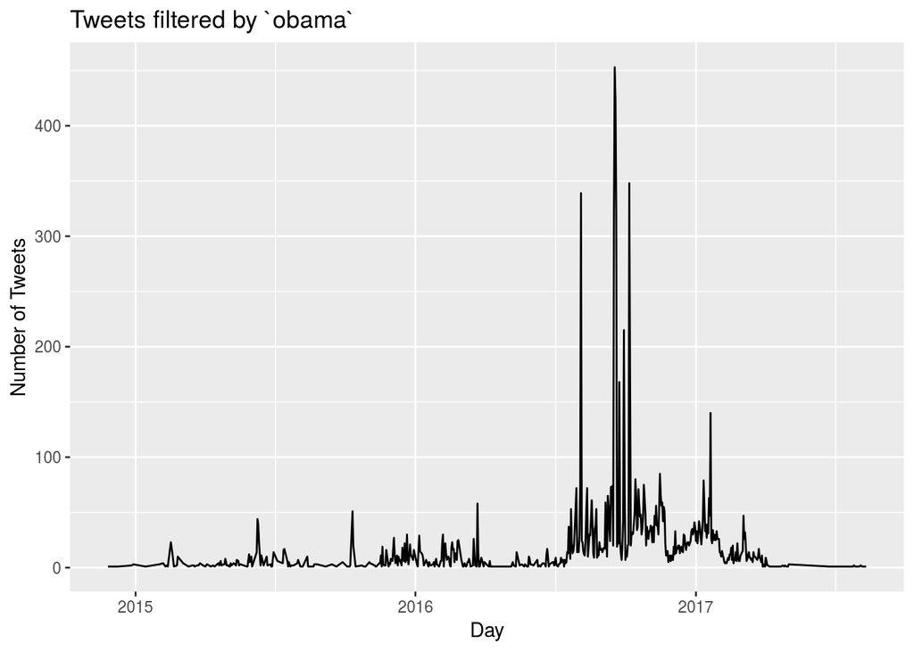

```r
# with full pipeline
term <- "obama"

q <- tweets %>%
  filter(str_detect(tolower(tweets$text), term)) %>%
  group_by(Date = as.Date(created_str)) %>%
  summarise(Count=n()) %>%
  ggplot(aes(x = Date, y = Count)) +
  geom_line() +
  labs(title = paste0("Tweets filtered by `",term,"`"),
  x = "Day",
  y = "Number of Tweets")

q
```

## first html widget: plotly

Last, let’s use the `plotly` package to make this ggplot interactive.

```r
# install.packages("plotly")
library(plotly)
ggplotly(q)
```

[interactive chart not shown]